# HW7

11

October 25, 2016

# Question 1

Write down a general regular expression to match the following:

1. Words with @ symbols in them, e.g., h@te or v|c0din

```r
test = c("h@te", "v|c0din", "@rt", "g@@dsh|z", "sameTBH", "CDT")
print(grep("\\@", test))
```

```
## [1] 1 3 4
```

2. An IP address (Four sets of 1 to 3 digits separated by periods, e.g., 100.12.162.0)

```r
test = c("100.12.162.0", "127.0.0.1", "192.168.1.1", "192.168.1.255", "0.0.0.0", "1.1.1.01", "30.168.1.255.1", "127.1","192.168.1.256","-1.2.3.4", "3...3")
print(grep("^(?:\\d{1,3}\\.|\\d{1,3}){4}$", test))
```

```
## [1] 1 2 3 4 5 6 8 9
```

3. An email address that ends with .com, .edu, .net, .org, or .gov

```r
test = c("dude@sbcglobal.net", "bro@gmail.com", "JACK_DANIELS@yahoo.com", "qrwa@121@.gov", "com.blah.www/mahHObbis", "huehuehuehue", "wizardSLEEVE@gmail.pl")
print(grep("^\\w+@{1}\\w+\\.{1}\\w+{1,3}", test))
```

```
## [1] 1 2 3 7
```

# Question 2

1. Use readLines() to read in the speeches (available as a text file in moodle) where the return value is: character vector with one element/character string per line in the file

```r
file = readLines("stateoftheunion1790-2012.txt")
```

2. Use regular expressions to find ***

```r
re = "[*]{3}"
speeches = grep(re,file)
```

3. Use *** to identify the date of the speech

```r
dates = file[speeches + 4]
dates = dates[!is.na(dates)]
head(dates,10)
```

```
##  [1] "January 8, 1790"   "December 8, 1790"  "October 25, 1791"
##  [4] "November 6, 1792"  "December 3, 1793"  "November 19, 1794"
##  [7] "December 8, 1795"  "December 7, 1796"  "November 22, 1797"
## [10] "December 8, 1798"
```

4. Use regular expressions to extract the year

```r
re = "[[:digit:]]{4}"
yearPositions = as.numeric(gregexpr(re, dates))
years = substr(dates, start=yearPositions, stop=yearPositions + 4)
head(years, 10)
```

```
##  [1] "1790" "1790" "1791" "1792" "1793" "1794" "1795" "1796" "1797" "1798"
```

5. Use regular expressions to extract the month

```r
re = "[0-9, ]"
months = gsub(pattern=re, replacement="", dates)
head(months, 10)
```

```
##  [1] "January"  "December" "October"  "November" "December" "November"
##  [7] "December" "December" "November" "December"
```

6. Use *** to extract the name of the president State of the union speeches

```r
presidents = file[speeches + 3]
presidents = presidents[!is.na(presidents)]
head(presidents,15)
```

```
##  [1] "George Washington" "George Washington" "George Washington"
##  [4] "George Washington" "George Washington" "George Washington"
##  [7] "George Washington" "George Washington" "John Adams"
## [10] "John Adams"        "John Adams"        "John Adams"
## [13] "Thomas Jefferson"  "Thomas Jefferson"  "Thomas Jefferson"
```

7. Use regular expressions and R to return the number of speeches in the dataset, and the number of presidents that gave speeches

Assume *** are nodes and speeches are edges, therefore document has n-1 speeches

```r
length(file[speeches]) - 1
```

```
## [1] 222
```

```r
length(unique(presidents))
```

```
## [1] 41
```

```r
unique(presidents)
```

```
##  [1] "George Washington"     "John Adams"
##  [3] "Thomas Jefferson"      "James Madison"
##  [5] "James Monroe"          "John Quincy Adams"
##  [7] "Andrew Jackson"        "Martin van Buren"
##  [9] "John Tyler"            "James Polk"
## [11] "Zachary Taylor"        "Millard Fillmore"
## [13] "Franklin Pierce"       "James Buchanan"
## [15] "Abraham Lincoln"       "Andrew Johnson"
## [17] "Ulysses S. Grant"      "Rutherford B. Hayes"
## [19] "Chester A. Arthur"     "Grover Cleveland"
## [21] "Benjamin Harrison"     "William McKinley"
## [23] "Theodore Roosevelt"    "William H. Taft"
## [25] "Woodrow Wilson"        "Warren Harding"
## [27] "Calvin Coolidge"       "Herbert Hoover"
## [29] "Franklin D. Roosevelt" "Harry S. Truman"
## [31] "Dwight D. Eisenhower"  "John F. Kennedy"
## [33] "Lyndon B. Johnson"     "Richard Nixon"
## [35] "Gerald R. Ford"        "Jimmy Carter"
## [37] "Ronald Reagan"         "George H.W. Bush"
## [39] "William J. Clinton"    "George W. Bush"
## [41] "Barack Obama"
```

8. Chop the speeches up into a list there is one element for each speech. Each element is a character vector. Check: does your number of list elements match your answer above?

```r
speechList = list()
for(i in 2:length(speeches)-1){
    speechList[[i]] = paste(file[(speeches[i] + 6):(speeches[i+1] - 1)], sep="", collapse=" ")
}
length(speechList)
```

```
## [1] 222
```

YES

1. Eliminate apostrophes, numbers, and the phrase: (Applause.)

```r
cleanSpeech = function(speech) {
    modSpeech = gsub(pattern="[[:punct:]]?[0-9'][[:punct:]]?", replacement="", x=speech)
    modSpeech = gsub(pattern="[[:punct:]]?Applause[[:punct:]]{0,2}", replacement="", x=modSpeech, ignore.case=T)
    return(modSpeech)
}

speechList = lapply(speechList, cleanSpeech)
```

10. Make all the characters lower case.

```r
speechList = tolower(speechList)
```

11. Split the sentences up where there are blanks and punctuation to create “words”

```r
speechList = strsplit(speechList, split="([[:blank:]]|[[:punct:]])")
```

12. Drop any empty words that resulted from this split.

```r
speechList[] = lapply(speechList[], function(x) x[x!=""])
```

13. Create a word vector for each speech.

```r
words = list()
uniqWords = numeric()
for(i in 1:length(speechList)) {
    uniqWords = c(uniqWords, length(unique(speechList[[i]])))
    words[[i]] = as.vector(table(speechList[[i]]))
}
```

14. Normalize the word vectors to get term frequencies.

```r
normWords = lapply(words[], function(x) x/sum(x))
```

15. Carry out some exploratory analysis of the data and term frequencies. For example, find the number of sentences, extract the long words, and the political party. Plot and interpret the term frequencies. What are your observations?

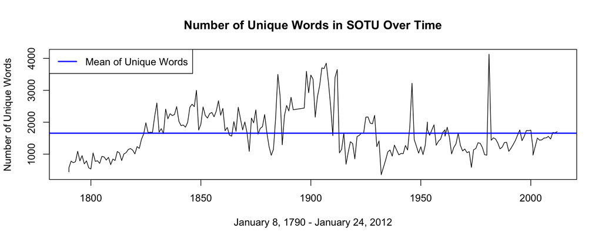

```r
plot(years, uniqWords, type="l",
    main="Number of Unique Words in SOTU Over Time",
    xlab="January 8, 1790 - January 24, 2012",
    ylab="Number of Unique Words")
abline(h=mean(uniqWords), col="blue", lwd=2)
legend('topleft', c("Mean of Unique Words"), lty=1, lwd=2, col="blue")
```